# Assignment 6: Visualization - Aesthetic Mapping

*How to do it?*:

- Open the Rmarkdown file of this assignment (link) in Rstudio.
- Right under each **question**, insert a code chunk (you can use the hotkey `Ctrl + Alt + I` to add a code chunk) and code the solution for the question.
- `Knit` the rmarkdown file (hotkey: `Ctrl + Alt + K`) to export an html.
- Publish the html file to your Githiub Page.

*Submission*: Submit the link on Github of the assignment to Blackboard.

**Questions**

Use the data of your own. Produce the following types of plots and comment on each plot. Plots should be meaningful. If you use the data we used in class, make sure the plots are not the same as the ones in the slides.

```r
library(tidyverse)
spotify=read_csv('data.csv')
str(spotify)
```

```
## tibble [169,909 x 19] (S3: spec_tbl_df/tbl_df/tbl/data.frame)
##  $ acousticness    : num [1:169909] 0.995 0.994 0.604 0.995 0.99 0.995 0.956 0.988 0.995 0.846 ...
##  $ artists         : chr [1:169909] "['Carl Woitschach']" "['Robert Schumann', 'Vladimir Horowitz']" "['Seweryn Goszczynski']" "['Francisco Canaro']" ...
##  $ danceability    : num [1:169909] 0.708 0.379 0.749 0.781 0.21 0.424 0.444 0.555 0.683 0.674 ...
##  $ duration_ms     : num [1:169909] 158648 282133 104300 180760 687733 ...
##  $ energy          : num [1:169909] 0.195 0.0135 0.22 0.13 0.204 0.12 0.197 0.421 0.207 0.205 ...
##  $ explicit        : num [1:169909] 0 0 0 0 0 0 0 0 0 0 ...
##  $ id              : chr [1:169909] "6KbQ3uYMLKb5jDxLF7wYDD" "6KuQTIu1KoTTkLXKrwlLPV" "6L63VW0PibdM1HDSBoqnoM" "6M94FkXd15sOAOQYRnWPN8" ...
##  $ instrumentalness: num [1:169909] 0.563 0.901 0 0.887 0.908 0.911 0.435 0.836 0.206 0 ...
##  $ key             : num [1:169909] 10 8 5 1 11 6 11 1 9 9 ...
##  $ liveness        : num [1:169909] 0.151 0.0763 0.119 0.111 0.098 0.0915 0.0744 0.105 0.337 0.17 ...
##  $ loudness        : num [1:169909] -12.4 -28.5 -19.9 -14.7 -16.8 ...
##  $ mode            : num [1:169909] 1 1 0 0 1 0 1 1 0 1 ...
##  $ name            : chr [1:169909] "Singende Bataillone 1. Teil" "Fantasiestücke, Op. 111: Più tosto lento" "Chapter 1.18 - Zamek kaniowski" "Bebamos Juntos - Instrumental (Remasterizado)" ...
##  $ popularity      : num [1:169909] 0 0 0 0 1 0 0 0 0 0 ...
##  $ release_date    : chr [1:169909] "1928" "1928" "1928" "1928-09-25" ...
##  $ speechiness     : num [1:169909] 0.0506 0.0462 0.929 0.0926 0.0424 0.0593 0.04 0.0474 0.127 0.954 ...
##  $ tempo           : num [1:169909] 118.5 84 107.2 108 62.1 ...
##  $ valence         : num [1:169909] 0.779 0.0767 0.88 0.72 0.0693 0.266 0.305 0.857 0.493 0.759 ...
##  $ year            : num [1:169909] 1928 1928 1928 1928 1928 ...
##  - attr(*, "spec")=
##   .. cols(
##   ..   acousticness = col_double(),
##   ..   artists = col_character(),
##   ..   danceability = col_double(),
##   ..   duration_ms = col_double(),
##   ..   energy = col_double(),
##   ..   explicit = col_double(),
##   ..   id = col_character(),
##   ..   instrumentalness = col_double(),
##   ..   key = col_double(),
##   ..   liveness = col_double(),
##   ..   loudness = col_double(),
##   ..   mode = col_double(),
##   ..   name = col_character(),
##   ..   popularity = col_double(),
##   ..   release_date = col_character(),
##   ..   speechiness = col_double(),
##   ..   tempo = col_double(),
##   ..   valence = col_double(),
##   ..   year = col_double()
##   .. )
```

```r
library(lubridate)
spotify$release_date <- ymd(spotify$release_date)
class(spotify$release_date)
```

```
## [1] "Date"
```

```r
#make ms into s
spotify %>% mutate(duration_s= duration_ms/1000)
```

```
## # A tibble: 169,909 x 20
##    acousticness artists danceability duration_ms energy explicit id
##           <dbl> <chr>          <dbl>       <dbl>  <dbl>    <dbl> <chr>
##  1        0.995 ['Carl~        0.708      158648 0.195         0 6KbQ~
##  2        0.994 ['Robe~        0.379      282133 0.0135        0 6KuQ~
##  3        0.604 ['Sewe~        0.749      104300 0.22          0 6L63~
##  4        0.995 ['Fran~        0.781      180760 0.13          0 6M94~
##  5        0.99  ['Fréd~        0.21       687733 0.204         0 6N6t~
##  6        0.995 ['Feli~        0.424      352600 0.12          0 6NxA~
##  7        0.956 ['Fran~        0.444      136627 0.197         0 6O0p~
##  8        0.988 ['Carl~        0.555      153967 0.421         0 6OJj~
##  9        0.995 ['Fran~        0.683      162493 0.207         0 6OaJ~
## 10        0.846 ['Sewe~        0.674      111600 0.205         0 6PrZ~
## # ... with 169,899 more rows, and 13 more variables: instrumentalness <dbl>,
## #   key <dbl>, liveness <dbl>, loudness <dbl>, mode <dbl>, name <chr>,
## #   popularity <dbl>, release_date <date>, speechiness <dbl>, tempo <dbl>,
## #   valence <dbl>, year <dbl>, duration_s <dbl>
```

1. For one continuous variable:
- Density
- Histogram
- Boxplot

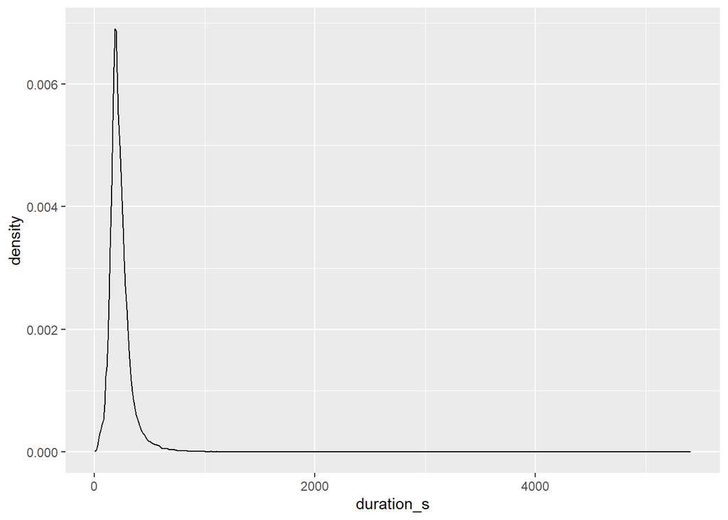

```r
library(ggplot2)
spotify %>% mutate(duration_s= duration_ms/1000) %>%
ggplot()+ aes(x=duration_s) + geom_density()
```

```r
#seeing where the density is the highest, most of the songs are in the same duration
```

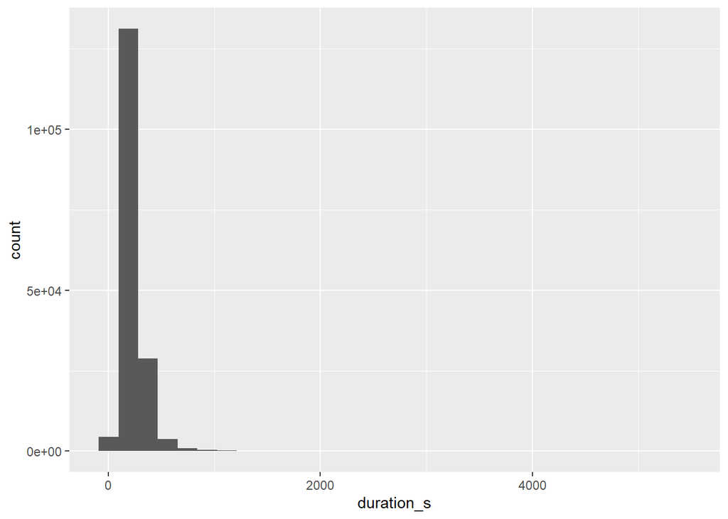

```r
library(ggplot2)
spotify %>% mutate(duration_s= duration_ms/1000) %>%
ggplot()+ aes(x=duration_s) + geom_histogram()
```

```r
#very similar to density plot
```